# Background and Context

You are a Data Scientist for a tourism company named "Visit with us". The Policy Maker of the company wants to enable and establish a viable business model to expand the customer base.

A viable business model is a central concept that helps you to understand the existing ways of doing the business and how to change the ways for the benefit of the tourism sector.

One of the ways to expand the customer base is to introduce a new offering of packages.

Currently, there are 5 types of packages the company is offering - Basic, Standard, Deluxe, Super Deluxe, King. Looking at the data of the last year, we observed that 18% of the customers purchased the packages.

However, it was difficult to identify the potential customers because customers were contacted at random without looking at the available information.

The company is now planning to launch a new product i.e. Wellness Tourism Package. Wellness Tourism is defined as Travel that allows the traveler to maintain, enhance or kick-start a healthy lifestyle, and support or increase one's sense of well-being.

This time company wants to harness the available data of existing and potential customers to target the right customers.

You as a Data Scientist at "Visit with us" travel company has to analyze the customers' data and information to provide recommendations to the Policy Maker and build a model to predict the potential customer who is going to purchase the newly introduced travel package. The model will be built to make predictions before a customer is contacted.

# Objective

To predict which customer is more likely to purchase the newly introduced travel package.

```python
import pandas as pd
import numpy as np
from sklearn import metrics
import matplotlib.pyplot as plt
from matplotlib.ticker import PercentFormatter
%matplotlib inline
import warnings
warnings.filterwarnings('ignore')
import seaborn as sns
from sklearn.model_selection import train_test_split
from sklearn.model_selection import GridSearchCV
from sklearn import metrics
from sklearn.linear_model import LogisticRegression
from sklearn.tree import DecisionTreeClassifier
from sklearn.ensemble import StackingClassifier
from sklearn.ensemble import AdaBoostClassifier, GradientBoostingClassifier, BaggingClassifier, RandomForestClassifier
from xgboost import XGBClassifier
```

```python
tour_df_raw = pd.read_excel('Tourism.xls',sheet_name = 'Tourism')
tour_df_raw.sample(10)
```

|  | CustomerID | ProdTaken | Age | TypeofContact | CityTier | DurationOfPitch | Occupation | Gender | NumberOfPersonVisiting | NumberOfFollowups | ProductPitched | PreferredPropertyStar | MaritalStatus | NumberOfTrips | Passport | PitchSatisfactionScore | OwnCar | NumberOfChildrenVisiting | Designation | MonthlyIncome |
| --- | --- | --- | --- | --- | --- | --- | --- | --- | --- | --- | --- | --- | --- | --- | --- | --- | --- | --- | --- | --- |
| 1060 | 201060 | 1 | 24.0 | Company Invited | 1 | 15.0 | Small Business | Male | 2 | 3.0 | Basic | 5.0 | Single | 3.0 | 1 | 3 | 0 | 1.0 | Executive | 18172.0 |
| 1508 | 201508 | 0 | NaN | Self Enquiry | 1 | 11.0 | Salaried | Female | 2 | 4.0 | Basic | 5.0 | Married | 1.0 | 1 | 1 | 1 | 1.0 | Executive | 18419.0 |
| 3748 | 203748 | 0 | 41.0 | Self Enquiry | 1 | 19.0 | Salaried | Female | 3 | 4.0 | Deluxe | 5.0 | Married | 4.0 | 0 | 1 | 1 | 2.0 | Manager | 23126.0 |
| 3638 | 203638 | 0 | 48.0 | Self Enquiry | 3 | 9.0 | Salaried | Female | 3 | 2.0 | Super Deluxe | 4.0 | Married | 8.0 | 0 | 1 | 0 | NaN | AVP | 34650.0 |
| 3093 | 203093 | 0 | 54.0 | Self Enquiry | 1 | 30.0 | Salaried | Female | 4 | 4.0 | Super Deluxe | 3.0 | Single | 8.0 | 0 | 5 | 1 | 2.0 | AVP | 32953.0 |
| 1642 | 201642 | 0 | 36.0 | Company Invited | 1 | 9.0 | Small Business | Male | 1 | 3.0 | Basic | 4.0 | Single | 5.0 | 0 | 4 | 1 | 0.0 | Executive | 17088.0 |
| 1708 | 201708 | 0 | NaN | Self Enquiry | 3 | 10.0 | Salaried | Female | 2 | 3.0 | Basic | 4.0 | Married | 3.0 | 0 | 3 | 1 | 1.0 | Executive | NaN |
| 4576 | 204576 | 1 | 21.0 | Self Enquiry | 3 | 9.0 | Small Business | Female | 3 | 5.0 | Basic | 3.0 | Single | 3.0 | 0 | 4 | 1 | 1.0 | Executive | 20722.0 |
| 4101 | 204101 | 0 | 56.0 | Self Enquiry | 1 | 21.0 | Small Business | Male | 4 | 2.0 | King | 4.0 | Single | NaN | 0 | 1 | 1 | 2.0 | VP | 37400.0 |
| 3033 | 203033 | 1 | 30.0 | Self Enquiry | 1 | 7.0 | Salaried | Female | 3 | 5.0 | Basic | 5.0 | Divorced | 3.0 | 1 | 2 | 0 | 1.0 | Executive | 20997.0 |

### Customer details:

##### Variable of interest

- ProdTaken: Whether the customer has purchased a package or not (0: No, 1: Yes)

##### Modeling variables

- CustomerID: Unique customer ID
- Age: Age of customer
- TypeofContact: How customer was contacted (Company Invited or Self Inquiry)
- CityTier: City tier depends on the development of a city, population, facilities, and living standards.
  - The categories are ordered i.e. Tier 1 > Tier 2 > Tier 3. It's the city the customer lives in.
- Occupation: Occupation of customer
- Gender: Gender of customer
- NumberOfPersonVisiting: Total number of persons planning to take the trip with the customer
- PreferredPropertyStar: Preferred hotel property rating by customer
- MaritalStatus: Marital status of customer
- NumberOfTrips: Average number of trips in a year by customer
- Passport: The customer has a passport or not (0: No, 1: Yes)
- OwnCar: Whether the customers own a car or not (0: No, 1: Yes)
- NumberOfChildrenVisiting: Total number of children with age less than 5 planning to take the trip with the customer
- Designation: Designation of the customer in the current organization
- MonthlyIncome: Gross monthly income of the customer
- Customer interaction data:
  - PitchSatisfactionScore: Sales pitch satisfaction score
  - ProductPitched: Product pitched by the salesperson
  - NumberOfFollowups: Total number of follow-ups has been done by the salesperson after the sales pitch
  - DurationOfPitch: Duration of the pitch by a salesperson to the customer

```python
tour_df_raw.info()
```

```
<class 'pandas.core.frame.DataFrame'>
RangeIndex: 4888 entries, 0 to 4887
Data columns (total 20 columns):
 #   Column                    Non-Null Count  Dtype
---  ------                    --------------  -----
 0   CustomerID                4888 non-null   int64
 1   ProdTaken                 4888 non-null   int64
 2   Age                       4662 non-null   float64
 3   TypeofContact             4863 non-null   object
 4   CityTier                  4888 non-null   int64
 5   DurationOfPitch           4637 non-null   float64
 6   Occupation                4888 non-null   object
 7   Gender                    4888 non-null   object
 8   NumberOfPersonVisiting    4888 non-null   int64
 9   NumberOfFollowups         4843 non-null   float64
 10  ProductPitched            4888 non-null   object
 11  PreferredPropertyStar     4862 non-null   float64
 12  MaritalStatus             4888 non-null   object
 13  NumberOfTrips             4748 non-null   float64
 14  Passport                  4888 non-null   int64
 15  PitchSatisfactionScore    4888 non-null   int64
 16  OwnCar                    4888 non-null   int64
 17  NumberOfChildrenVisiting  4822 non-null   float64
 18  Designation               4888 non-null   object
 19  MonthlyIncome             4655 non-null   float64
dtypes: float64(7), int64(7), object(6)
memory usage: 763.9+ KB
```

```python
tour_df_raw.describe().T
```

|  | count | mean | std | min | 25% | 50% | 75% | max |
| --- | --- | --- | --- | --- | --- | --- | --- | --- |
| CustomerID | 4888.0 | 202443.500000 | 1411.188388 | 200000.0 | 201221.75 | 202443.5 | 203665.25 | 204887.0 |
| ProdTaken | 4888.0 | 0.188216 | 0.390925 | 0.0 | 0.00 | 0.0 | 0.00 | 1.0 |
| Age | 4662.0 | 37.622265 | 9.316387 | 18.0 | 31.00 | 36.0 | 44.00 | 61.0 |
| CityTier | 4888.0 | 1.654255 | 0.916583 | 1.0 | 1.00 | 1.0 | 3.00 | 3.0 |
| DurationOfPitch | 4637.0 | 15.490835 | 8.519643 | 5.0 | 9.00 | 13.0 | 20.00 | 127.0 |
| NumberOfPersonVisiting | 4888.0 | 2.905074 | 0.724891 | 1.0 | 2.00 | 3.0 | 3.00 | 5.0 |
| NumberOfFollowups | 4843.0 | 3.708445 | 1.002509 | 1.0 | 3.00 | 4.0 | 4.00 | 6.0 |
| PreferredPropertyStar | 4862.0 | 3.581037 | 0.798009 | 3.0 | 3.00 | 3.0 | 4.00 | 5.0 |
| NumberOfTrips | 4748.0 | 3.236521 | 1.849019 | 1.0 | 2.00 | 3.0 | 4.00 | 22.0 |
| Passport | 4888.0 | 0.290917 | 0.454232 | 0.0 | 0.00 | 0.0 | 1.00 | 1.0 |
| PitchSatisfactionScore | 4888.0 | 3.078151 | 1.365792 | 1.0 | 2.00 | 3.0 | 4.00 | 5.0 |
| OwnCar | 4888.0 | 0.620295 | 0.485363 | 0.0 | 0.00 | 1.0 | 1.00 | 1.0 |
| NumberOfChildrenVisiting | 4822.0 | 1.187267 | 0.857861 | 0.0 | 1.00 | 1.0 | 2.00 | 3.0 |
| MonthlyIncome | 4655.0 | 23619.853491 | 5380.698361 | 1000.0 | 20346.00 | 22347.0 | 25571.00 | 98678.0 |

```python
tour_df_raw.describe(include=[object]).T
```

|  | count | unique | top | freq |
| --- | --- | --- | --- | --- |
| TypeofContact | 4863 | 2 | Self Enquiry | 3444 |
| Occupation | 4888 | 4 | Salaried | 2368 |
| Gender | 4888 | 3 | Male | 2916 |
| ProductPitched | 4888 | 5 | Basic | 1842 |
| MaritalStatus | 4888 | 4 | Married | 2340 |
| Designation | 4888 | 5 | Executive | 1842 |

```python
def null_val(df,flag=True):
    nan_vals = df.isna().sum().sort_values(ascending=False)
    nan_vals_perc = 100 * nan_vals/len(df)

    nan_val_df = pd.concat([nan_vals, nan_vals_perc.round(2).astype(str)+' %'], axis=1).reset_index()
    if flag == True:
        print(nan_val_df)

    return nan_val_df['index'].loc[nan_val_df[0]!=0].values

null_val(tour_df_raw)
```

```
                       index    0       1
0            DurationOfPitch  251  5.14 %
1              MonthlyIncome  233  4.77 %
2                        Age  226  4.62 %
3              NumberOfTrips  140  2.86 %
4   NumberOfChildrenVisiting   66  1.35 %
5          NumberOfFollowups   45  0.92 %
6      PreferredPropertyStar   26  0.53 %
7              TypeofContact   25  0.51 %
8                   Passport    0   0.0 %
9              MaritalStatus    0   0.0 %
10            ProductPitched    0   0.0 %
11               Designation    0   0.0 %
12    NumberOfPersonVisiting    0   0.0 %
13                    Gender    0   0.0 %
14                Occupation    0   0.0 %
15    PitchSatisfactionScore    0   0.0 %
16                  CityTier    0   0.0 %
17                    OwnCar    0   0.0 %
18                 ProdTaken    0   0.0 %
19                CustomerID    0   0.0 %
```

```
array(['DurationOfPitch', 'MonthlyIncome', 'Age', 'NumberOfTrips',
       'NumberOfChildrenVisiting', 'NumberOfFollowups',
       'PreferredPropertyStar', 'TypeofContact'], dtype=object)
```

```python
nan_df = tour_df_raw[tour_df_raw.isnull().any(axis=1)]

nan_df
```

|  | CustomerID | ProdTaken | Age | TypeofContact | CityTier | DurationOfPitch | Occupation | Gender | NumberOfPersonVisiting | NumberOfFollowups | ProductPitched | PreferredPropertyStar | MaritalStatus | NumberOfTrips | Passport | PitchSatisfactionScore | OwnCar | NumberOfChildrenVisiting | Designation | MonthlyIncome |
| --- | --- | --- | --- | --- | --- | --- | --- | --- | --- | --- | --- | --- | --- | --- | --- | --- | --- | --- | --- | --- |
| 4 | 200004 | 0 | NaN | Self Enquiry | 1 | 8.0 | Small Business | Male | 2 | 3.0 | Basic | 4.0 | Divorced | 1.0 | 0 | 5 | 1 | 0.0 | Executive | 18468.0 |
| 11 | 200011 | 0 | NaN | Self Enquiry | 1 | 21.0 | Salaried | Female | 2 | 4.0 | Deluxe | 3.0 | Single | 1.0 | 1 | 3 | 0 | 0.0 | Manager | NaN |
| 19 | 200019 | 0 | NaN | Self Enquiry | 1 | 8.0 | Salaried | Male | 2 | 3.0 | Basic | 3.0 | Single | 6.0 | 1 | 4 | 0 | 1.0 | Executive | NaN |
| 20 | 200020 | 0 | NaN | Company Invited | 1 | 17.0 | Salaried | Female | 3 | 2.0 | Deluxe | 3.0 | Married | 1.0 | 0 | 3 | 1 | 2.0 | Manager | NaN |
| 21 | 200021 | 1 | NaN | Self Enquiry | 3 | 15.0 | Salaried | Male | 2 | 4.0 | Deluxe | 5.0 | Single | 1.0 | 0 | 2 | 0 | 0.0 | Manager | 18407.0 |
| ... | ... | ... | ... | ... | ... | ... | ... | ... | ... | ... | ... | ... | ... | ... | ... | ... | ... | ... | ... | ... |
| 4850 | 204850 | 1 | 46.0 | Self Enquiry | 3 | 8.0 | Salaried | Male | 4 | 5.0 | Deluxe | 5.0 | Married | NaN | 0 | 4 | 1 | 3.0 | Manager | 36739.0 |
| 4851 | 204851 | 1 | 40.0 | Self Enquiry | 1 | 9.0 | Salaried | Female | 4 | 4.0 | Basic | 5.0 | Married | NaN | 1 | 1 | 1 | 1.0 | Executive | 35801.0 |
| 4868 | 204868 | 1 | 43.0 | Company Invited | 2 | 15.0 | Salaried | Female | 4 | 5.0 | Basic | 3.0 | Married | NaN | 0 | 5 | 1 | 2.0 | Executive | 36539.0 |
| 4869 | 204869 | 1 | 56.0 | Self Enquiry | 3 | 16.0 | Small Business | Female | 3 | 6.0 | Basic | 4.0 | Single | NaN | 0 | 1 | 1 | 2.0 | Executive | 37865.0 |
| 4870 | 204870 | 1 | 57.0 | Self Enquiry | 3 | 23.0 | Salaried | Female | 4 | 4.0 | Standard | NaN | Single | 4.0 | 1 | 5 | 1 | 3.0 | Senior Manager | 38395.0 |

760 rows × 20 columns

### Missing/Null values

Here we have 8 variables with missing values. For Number of Follow Ups, Preferred Property Star and Type of contact will suredly be handled by the appropriate median substitution since there as so few missing that it would not really the resulting models.

For the rest of the variables the following approach is proposed:

- Number of children could be related to number of people visiting. (E.g. if it says 2, it should most likely substituted with 0, since a single parent taking a trip with their child would most likely account for their child.)
- The Monthly Income would likely be able to be approximated using the median or mean for the corresponding Occupation.
- Age, Duration of Pitch and Number of Trips are likely better handled by median substitution, unless strong correlation found with another variable that is complete

```python
nan_cols_I = null_val(tour_df_raw)
```

```
                       index    0       1
0            DurationOfPitch  251  5.14 %
1              MonthlyIncome  233  4.77 %
2                        Age  226  4.62 %
3              NumberOfTrips  140  2.86 %
4   NumberOfChildrenVisiting   66  1.35 %
5          NumberOfFollowups   45  0.92 %
6      PreferredPropertyStar   26  0.53 %
7              TypeofContact   25  0.51 %
8                   Passport    0   0.0 %
9              MaritalStatus    0   0.0 %
10            ProductPitched    0   0.0 %
11               Designation    0   0.0 %
12    NumberOfPersonVisiting    0   0.0 %
13                    Gender    0   0.0 %
14                Occupation    0   0.0 %
15    PitchSatisfactionScore    0   0.0 %
16                  CityTier    0   0.0 %
17                    OwnCar    0   0.0 %
18                 ProdTaken    0   0.0 %
19                CustomerID    0   0.0 %
```

```
DurationOfPitch
```

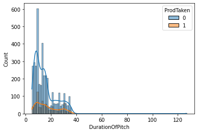

```
MonthlyIncome
```

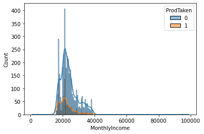

```
Age
```

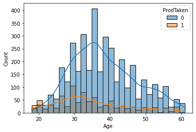

```
NumberOfTrips
```

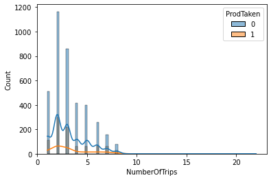

```
NumberOfChildrenVisiting
```

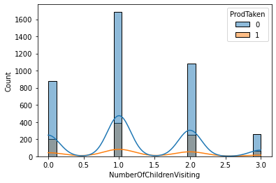

```
NumberOfFollowups
```

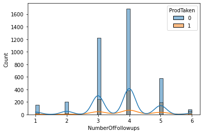

```
PreferredPropertyStar
```

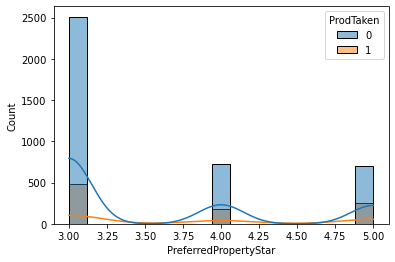

```
TypeofContact
```

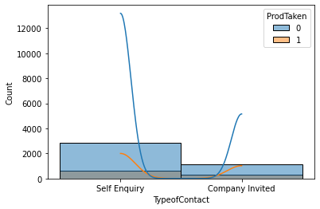

```python
cols_w_missing = tour_df_raw[list(nan_cols_I)+['ProdTaken']]

for col in nan_cols_I:
    print(col)
    sns.histplot(data=cols_w_missing,x=col,kde=True,hue='ProdTaken')
    plt.show()
```

```python
# Variables with small missing values
small_missing = nan_cols_I[-3:-1]

tour_df_fix = tour_df_raw.copy()

[tour_df_fix[x].fillna(tour_df_fix[x].median(),inplace=True) for x in small_missing]
tour_df_fix['TypeofContact'].fillna(tour_df_fix['TypeofContact'].mode()[0],inplace=True)

nan_cols_II = null_val(tour_df_fix)
```

```
                       index    0       1
0            DurationOfPitch  251  5.14 %
1              MonthlyIncome  233  4.77 %
2                        Age  226  4.62 %
3              NumberOfTrips  140  2.86 %
4   NumberOfChildrenVisiting   66  1.35 %
5     NumberOfPersonVisiting    0   0.0 %
6                  ProdTaken    0   0.0 %
7              TypeofContact    0   0.0 %
8                   CityTier    0   0.0 %
9                 Occupation    0   0.0 %
10                    Gender    0   0.0 %
11         NumberOfFollowups    0   0.0 %
12               Designation    0   0.0 %
13            ProductPitched    0   0.0 %
14     PreferredPropertyStar    0   0.0 %
15             MaritalStatus    0   0.0 %
16                  Passport    0   0.0 %
17    PitchSatisfactionScore    0   0.0 %
18                    OwnCar    0   0.0 %
19                CustomerID    0   0.0 %
```

- Checking out the distribution of people going with respect to their marital status
  - Hopefully information on the # of people and family structure could give some information

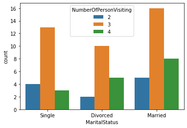

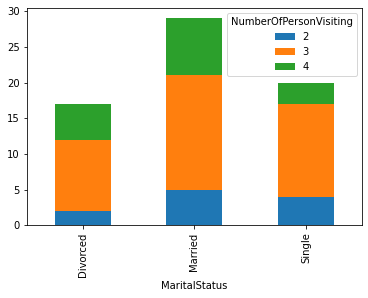

| NumberOfPersonVisiting MaritalStatus | 2 | 3 | 4 |
| --- | --- | --- | --- |
| Divorced | 2 | 10 | 5 |
| Married | 5 | 16 | 8 |
| Single | 4 | 13 | 3 |

```python
null_children = tour_df_fix.loc[tour_df_fix['NumberOfChildrenVisiting'].isnull()]
sns.countplot(data = null_children,
x='MaritalStatus',
hue='NumberOfPersonVisiting')
plt.show()
df_countplot = null_children.groupby(['MaritalStatus','NumberOfPersonVisiting']).size().reset_index().pivot(columns='NumberOfPersonVisiting', index='MaritalStatus', values=0)
df_countplot.plot(kind='bar', stacked=True)
plt.show()
display(df_countplot)
```

- Checking out the same distribution of people going with respect to their marital status for people who are bringing at least one child

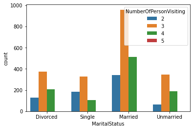

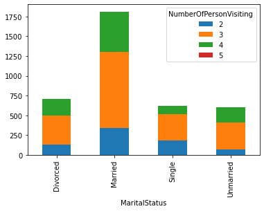

| NumberOfPersonVisiting MaritalStatus | 2 | 3 | 4 | 5 |
| --- | --- | --- | --- | --- |
| Divorced | 128.0 | 373.0 | 206.0 | NaN |
| Married | 343.0 | 958.0 | 511.0 | 1.0 |
| Single | 186.0 | 329.0 | 104.0 | 1.0 |
| Unmarried | 65.0 | 345.0 | 189.0 | 1.0 |

```python
null_children = tour_df_fix.loc[~tour_df_fix['NumberOfChildrenVisiting'].isnull() & tour_df_fix['NumberOfChildrenVisiting']>0]
sns.countplot(data = null_children,
x='MaritalStatus',
hue='NumberOfPersonVisiting')
plt.show()
df_countplot = null_children.groupby(['MaritalStatus','NumberOfPersonVisiting']).size().reset_index().pivot(columns='NumberOfPersonVisiting', index='MaritalStatus', values=0)
df_countplot.plot(kind='bar', stacked=True)
plt.show()
display(df_countplot)
```

Observing that the distribution of number of people visiting with respect of their marital status is fairly similar between people with null values and people bringing their children, I think it is enough to simply utilize the median value for these null values.

While children are usually an important variable for customers when deciding to vacation, handling these null values any other way would either require large/unfounded assumptions of this population or an amount of detailed EDA that outweights the percentage of missing data.

```python
tour_df_fix['NumberOfChildrenVisiting'].fillna(tour_df_fix['NumberOfChildrenVisiting'].median(),inplace=True)
nan_cols_III = null_val(tour_df_fix)
```

```
                       index    0       1
0            DurationOfPitch  251  5.14 %
1              MonthlyIncome  233  4.77 %
2                        Age  226  4.62 %
3              NumberOfTrips  140  2.86 %
4     NumberOfPersonVisiting    0   0.0 %
5                  ProdTaken    0   0.0 %
6              TypeofContact    0   0.0 %
7                   CityTier    0   0.0 %
8                 Occupation    0   0.0 %
9                     Gender    0   0.0 %
10         NumberOfFollowups    0   0.0 %
11               Designation    0   0.0 %
12            ProductPitched    0   0.0 %
13     PreferredPropertyStar    0   0.0 %
14             MaritalStatus    0   0.0 %
15                  Passport    0   0.0 %
16    PitchSatisfactionScore    0   0.0 %
17                    OwnCar    0   0.0 %
18  NumberOfChildrenVisiting    0   0.0 %
19                CustomerID    0   0.0 %
```

Jumping to Monthly Income would now be prudent given that there is a variable (i.e. CityTier) that could guide handling missing values

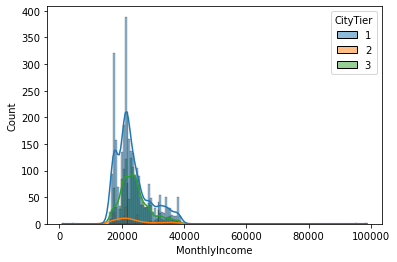

```python
sns.histplot(data=tour_df_fix,x='MonthlyIncome',hue='CityTier',kde=True,palette='tab10')
```

While unexpected, the fact that there is no shift in distribution between the different city tier, and the spread of the monthly incomes themselves are pretty concentrated around 20k a month would indicate that substituting missing values with median. Mean should be avoided in this imputation process given the presence of extreme outliers from the distribution from City Tier 1.

```python
tour_df_fix['MonthlyIncome'].fillna(tour_df_fix['MonthlyIncome'].median(),inplace=True)
nan_cols_III = null_val(tour_df_fix)
```

```
                       index    0       1
0            DurationOfPitch  251  5.14 %
1                        Age  226  4.62 %
2              NumberOfTrips  140  2.86 %
3              MonthlyIncome    0   0.0 %
4     NumberOfPersonVisiting    0   0.0 %
5                  ProdTaken    0   0.0 %
6              TypeofContact    0   0.0 %
7                   CityTier    0   0.0 %
8                 Occupation    0   0.0 %
9                     Gender    0   0.0 %
10         NumberOfFollowups    0   0.0 %
11               Designation    0   0.0 %
12            ProductPitched    0   0.0 %
13     PreferredPropertyStar    0   0.0 %
14             MaritalStatus    0   0.0 %
15                  Passport    0   0.0 %
16    PitchSatisfactionScore    0   0.0 %
17                    OwnCar    0   0.0 %
18  NumberOfChildrenVisiting    0   0.0 %
19                CustomerID    0   0.0 %
```

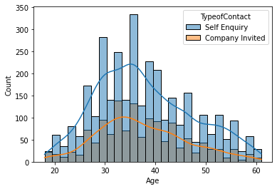

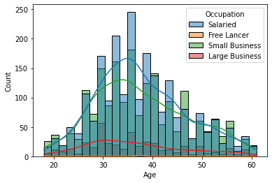

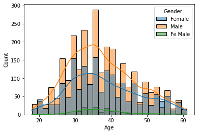

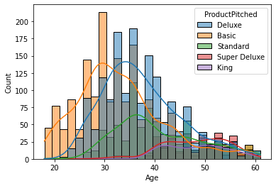

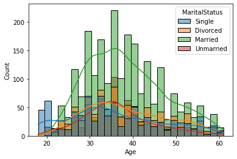

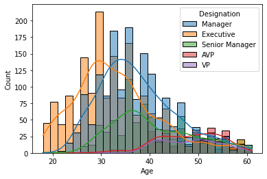

```python
cat_vars = tour_df_fix.select_dtypes(exclude='number').columns

for x in cat_vars:
    sns.histplot(data=tour_df_fix,x='Age',kde=True, hue=x,palette='tab10')
    plt.show()
```

We can see that only for Product Pitched and Designation there is a shift in the Age distributions to have a better approximation of which median to use for the missing values, given that the Age variable had such a large spread.

(The fact that Prod.Pitched and Designation are so similar could point to a strong covariance which should be addressed during the multivariate analysis).

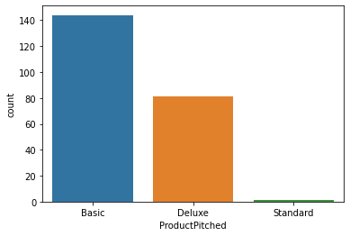

```python
# Let's check the distribution of the Product Pitched values for the customers for which Age entry was missing
null_age = tour_df_fix.loc[tour_df_fix['Age'].isnull()]

sns.countplot(data=null_age,x='ProductPitched')
```

```python
vars = ['Basic','Deluxe','Standard']
for var in vars:
    val = tour_df_fix['Age'].loc[tour_df_fix['ProductPitched']==var].median()
    null_age['Age'].loc[null_age['ProductPitched']==var]=val

tour_df_fix = null_age.combine_first(tour_df_fix)

nan_cols_IV = null_val(tour_df_fix)
```

```
                       index    0       1
0            DurationOfPitch  251  5.14 %
1              NumberOfTrips  140  2.86 %
2              MonthlyIncome    0   0.0 %
3     NumberOfPersonVisiting    0   0.0 %
4                  ProdTaken    0   0.0 %
5                        Age    0   0.0 %
6              TypeofContact    0   0.0 %
7                   CityTier    0   0.0 %
8                 Occupation    0   0.0 %
9                     Gender    0   0.0 %
10         NumberOfFollowups    0   0.0 %
11               Designation    0   0.0 %
12            ProductPitched    0   0.0 %
13     PreferredPropertyStar    0   0.0 %
14             MaritalStatus    0   0.0 %
15                  Passport    0   0.0 %
16    PitchSatisfactionScore    0   0.0 %
17                    OwnCar    0   0.0 %
18  NumberOfChildrenVisiting    0   0.0 %
19                CustomerID    0   0.0 %
```

Given the effectiveness of the previous approach and the large number of missing values for the remaining two variables, a similar approach is suggested.

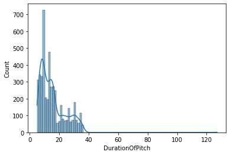

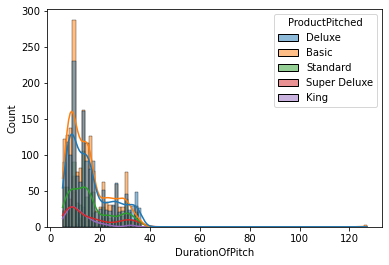

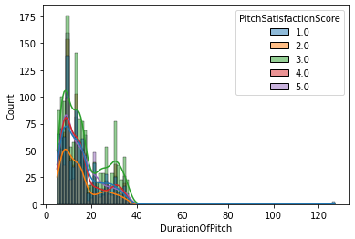

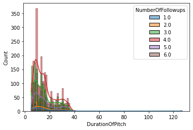

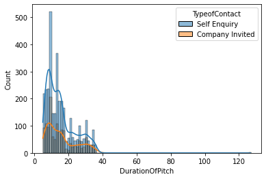

```python
pitch_vars = ['ProductPitched','PitchSatisfactionScore','NumberOfFollowups','TypeofContact']

sns.histplot(data=tour_df_fix,x='DurationOfPitch',kde=True)
plt.show()

for x in pitch_vars:
    sns.histplot(data=tour_df_fix,x='DurationOfPitch',kde=True, hue=x, palette='tab10')
    plt.show()
```

```
                       index    0       1
0              NumberOfTrips  140  2.86 %
1              MonthlyIncome    0   0.0 %
2     NumberOfPersonVisiting    0   0.0 %
3                  ProdTaken    0   0.0 %
4                        Age    0   0.0 %
5              TypeofContact    0   0.0 %
6                   CityTier    0   0.0 %
7            DurationOfPitch    0   0.0 %
8                 Occupation    0   0.0 %
9                     Gender    0   0.0 %
10         NumberOfFollowups    0   0.0 %
11               Designation    0   0.0 %
12            ProductPitched    0   0.0 %
13     PreferredPropertyStar    0   0.0 %
14             MaritalStatus    0   0.0 %
15                  Passport    0   0.0 %
16    PitchSatisfactionScore    0   0.0 %
17                    OwnCar    0   0.0 %
18  NumberOfChildrenVisiting    0   0.0 %
19                CustomerID    0   0.0 %
```

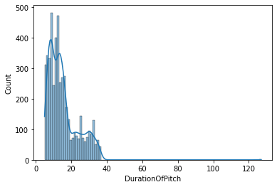

```python
tour_df_fix['DurationOfPitch'].fillna(tour_df_fix['DurationOfPitch'].median(),inplace=True)
nan_cols_V = null_val(tour_df_fix)
sns.histplot(data=tour_df_fix,x='DurationOfPitch',kde=True)
plt.show()
```

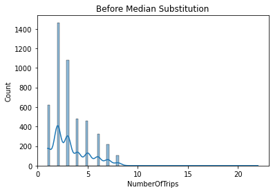

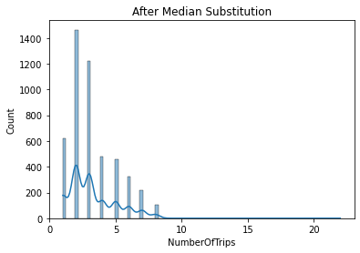

```
                       index  0      1
0              MonthlyIncome  0  0.0 %
1                Designation  0  0.0 %
2                  ProdTaken  0  0.0 %
3                        Age  0  0.0 %
4              TypeofContact  0  0.0 %
5                   CityTier  0  0.0 %
6            DurationOfPitch  0  0.0 %
7                 Occupation  0  0.0 %
8                     Gender  0  0.0 %
9     NumberOfPersonVisiting  0  0.0 %
10         NumberOfFollowups  0  0.0 %
11            ProductPitched  0  0.0 %
12     PreferredPropertyStar  0  0.0 %
13             MaritalStatus  0  0.0 %
14             NumberOfTrips  0  0.0 %
15                  Passport  0  0.0 %
16    PitchSatisfactionScore  0  0.0 %
17                    OwnCar  0  0.0 %
18  NumberOfChildrenVisiting  0  0.0 %
19                CustomerID  0  0.0 %
```

```
array([], dtype=object)
```

```python
sns.histplot(data=tour_df_fix,x='NumberOfTrips',kde=True)
plt.title('Before Median Substitution')
plt.show()

tour_df_fix['NumberOfTrips'].fillna(tour_df_fix['NumberOfTrips'].median(),inplace=True)

sns.histplot(data=tour_df_fix,x='NumberOfTrips',kde=True)
plt.title('After Median Substitution')
plt.show()

null_val(tour_df_fix)
```

```python
# Ensuring that all the identity of values are appropriate
for x in tour_df_fix.columns:
    uniquevals = tour_df_fix[x].unique()
    if len(uniquevals)<100:
        print('The ',len(uniquevals), 'unique values for the variable ', x, ' are: ')
        print(uniquevals)
        print()
```

```
The  2 unique values for the variable  ProdTaken  are:
[1. 0.]

The  44 unique values for the variable  Age  are:
[41. 49. 37. 33. 32. 59. 30. 38. 36. 35. 31. 34. 28. 29. 22. 53. 21. 42.
 44. 46. 39. 24. 43. 50. 27. 26. 48. 55. 45. 56. 23. 51. 40. 54. 58. 20.
 25. 19. 57. 52. 47. 18. 60. 61.]

The  2 unique values for the variable  TypeofContact  are:
['Self Enquiry' 'Company Invited']

The  3 unique values for the variable  CityTier  are:
[3. 1. 2.]

The  34 unique values for the variable  DurationOfPitch  are:
[  6.  14.   8.   9.  30.  29.  33.  22.  21.  32.  25.  27.  11.  17.
  15.  13.  12.  16.  10.  31.  18.  24.  35.  28.  20.  26.  34.  23.
   5.  19. 126.   7.  36. 127.]

The  4 unique values for the variable  Occupation  are:
['Salaried' 'Free Lancer' 'Small Business' 'Large Business']

The  3 unique values for the variable  Gender  are:
['Female' 'Male' 'Fe Male']

The  5 unique values for the variable  NumberOfPersonVisiting  are:
[3. 2. 1. 4. 5.]

The  6 unique values for the variable  NumberOfFollowups  are:
[3. 4. 2. 5. 1. 6.]

The  5 unique values for the variable  ProductPitched  are:
['Deluxe' 'Basic' 'Standard' 'Super Deluxe' 'King']

The  3 unique values for the variable  PreferredPropertyStar  are:
[3. 4. 5.]

The  4 unique values for the variable  MaritalStatus  are:
['Single' 'Divorced' 'Married' 'Unmarried']

The  12 unique values for the variable  NumberOfTrips  are:
[ 1.  2.  7.  5.  6.  3.  4. 19. 21.  8. 20. 22.]

The  2 unique values for the variable  Passport  are:
[1. 0.]

The  5 unique values for the variable  PitchSatisfactionScore  are:
[2. 3. 5. 4. 1.]

The  2 unique values for the variable  OwnCar  are:
[1. 0.]

The  4 unique values for the variable  NumberOfChildrenVisiting  are:
[0. 2. 1. 3.]

The  5 unique values for the variable  Designation  are:
['Manager' 'Executive' 'Senior Manager' 'AVP' 'VP']
```

We see two main issues:

- Gender variable contains more than two options
- There is a high likelihood that NumberOfTrips and DurationOfPitch have outliers

```python
tour_df_fix['Gender'].loc[tour_df_fix['Gender']!='Male'] = 'Female'

tour_df_fix['Gender'].unique()
```

```
array(['Female', 'Male'], dtype=object)
```